### Monitoria 4 - MQO - Inferência e teste de hipóteses.

Nome: Lucas Martins de Farias Fernandes  
Email: Lucasmffernandes@gmail.com

```r
#setup
# install.packages('latex2exp')
library(latex2exp)
library(tidyverse)
library(wooldridge)
```

#### **1. Distribuições amostrais dos estimadores de MQO.**

As distribuições amostrais dos coeficientes do MQO vão depender da distribuição dos próprios erros,$u$. Por isso, adotaremos mais uma hipótese para que seja possível realizar inferência sobre os coeficientes:

**Normalidade**

O erro populacional u é independente das variáveis explicativas $x_1,x_2,...,x_k$ e é normalmente distribuído com média zero e variância. Formalizando:

$u \sim Normal(0,\sigma^2)$

A justificativa para essa hipótese vem do teorema do limite central (TLC). De forma resumida, o TLC diz que quanto maior a amostra mais a distribuição amostral da sua média se aproxima de uma distribuição normal. A hipótese de normalidade e as hipóteses de GAUSS-MARKOV são chamadas de **hipóteses do modelo linear clássico (MLC)**. Através delas, podemos afirmar que os estimados do MQO são não viesados e tem variância mínima. O que significa que o MQO tem a menor variância entre os estimadores não viesados.

A normalidade dos erros é refletida nas distribuições amostrais dos estimadores do MQO. Formalizando:

> **- TEOREMA**

> Sob a hipótese de normalidade e as hipóteses de GAUSS-MARKOV, os coeficientes $\beta_j$(que são funções lineares de $u$) apresentam distribuição normal com:

> $\hat{\beta_j} \sim Normal(\beta_j,\sigma^2_{\hat{\beta_1}})$

> Pelas propriedades da distribuição normal, a variável Z, que é definida como:

> $Z = \frac{\hat{\beta_j} - \beta_j}{\sigma_{\hat{\beta_1}}}$

> Segue uma distribuição normal padrão, com média zero e variância unitária:

> $Z = \frac{\hat{\beta_j} - \beta_j}{\sigma_{\hat{\beta_1}}} \sim Normal(0,1)$

> Repare que para construir o teorema utilizamos a verdadeira variância populacional,$\sigma^2$. Na prática, a variância populacional é raramente conhecida, portanto, utilizaremos seu estimador não viesado, $\hat{\sigma^2}$. Dessa forma, em vez de usarmos a distribuição normal, podemos usar a distribuição t para inferir sobre os coeficientes do MQO. Formalizando:

> $t = \frac{\hat{\beta_j} - \beta_j}{\hat{\sigma}_{\hat{\beta_1}}} \sim t_{n-k-1} = t_{df}$

> em que $K + 1$ é o número de parâmetros desconhecidos do modelo populacional,y, e $df =n - k - 1$

#### **2. Teste de hipóteses: Teste de significância estatísticas dos coeficientes de MQO**

##### **2.1 Hipóteses nulas e estatística t**

O teste de significância é um procedimento em que os resultados amostrais são usados para verificar a veracidade ou não de uma hipótese nula, $H_0$. Na análise de uma regressão, faremos isso com base na estatística t, que definimos anteriormente, e um valor crítico, referente ao nível de significância escolhido.

Primeiramente, para aplicarmos o teste devemos definir nossa hipótese nula. Na maioria das aplicações, utilizaremos:

$H_0:\hat{\beta_j} = 0$

Para testar essa hipótese precisamos calcular a estatística t, que, nesse caso, é definida como:

$t_{\hat{\beta_j}} \equiv \frac{\hat{\beta_j}}{dp(\hat{\beta_j})}$

> Importante ressaltar que a hipótese nula apresentada, apesar de ser a mais comum, não é a única utilizada. Podemos testar sob hipóteses do tipo:

> $H_0:\beta_j = a_j$

> Nesse caso, testamos se o coeficiente é igual a uma constante, $a_j$, hipotética. Diante disso, a estatística t apropriada é dada por:

> $t = \frac{(\hat{\beta_j} - a_j)}{ep(\hat{\beta_j})}$

> Reparem que se adotarmos um $a_j = 0$, a hipótese nula e a estatística t serão as mesmas que apresentamos anteriormente. Nota-se então que a hipótese do tipo $H_0:\hat{\beta_j} = 0$ é um caso mais específico da hipótese $H_0:\beta_j = a_j$. O mesmo será valido para a forma que construímos a estatística t:

> $t = \frac{(\hat{\beta_j} - 0 )}{ep(\hat{\beta_j})} = \frac{\hat{\beta_j}}{ep(\hat{\beta_j})}$

##### **2.2 A hipótese alternativa.**

Para determinar uma regra para rejeitar a hipótese nula, $H_0$, precisamos decidir sobre a hipótese alternativa, $H_1$, relevante. Considerando a hipótese que fizemos anteriormente, adotaremos uma hipótese alternativa bicaudal(bilateral), do tipo:

$H_1:\hat{\beta_j} \neq 0$

Repare que a hipótese alternativa engloba sempre o conjunto que não é capturado pela hipótese nula. Se adotarmos, por exemplo, uma hipótese nula unilateral superior (Com cauda direita

$H_0:\hat{\beta_j} \leq 0$

A hipótese alternativa irá capturar o conjunto dos números maiores que 0:

$H_1:\hat{\beta_j} > 0$

As hipóteses nulas e alternativas possíveis estão resumidas no quadro:

[output not shown]

##### **2.3 Nível de significância, $\alpha$.**

Definido a hipótese nula e alternativa, escolhemos o nível de significância, $\alpha$. Juntamente com os graus de liberdade (gl ou df), o nível de significância irá delimitar o valor e a região crítica contra a qual vamos comparar a estatística t. Em econometria, usualmente utilizamos um nível de significância de 5%.

Portanto, considerando a hipótese nula:

$H_0:\hat{\beta_j} = 0$.

A regra de rejeição será dada por:

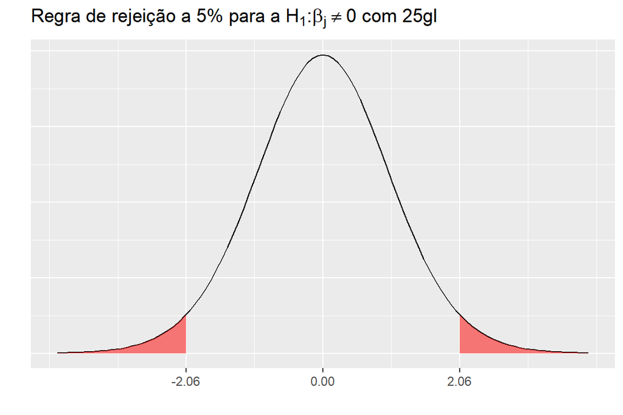

```r
plot_dis_t <- ggplot(data.frame(x = c(-4, 4)), aes(x)) +
  stat_function(fun = dt,args=list(df =25)) +
  theme(axis.text.y = element_blank(),axis.ticks.y = element_blank()) +
  xlab("") +
  ylab("")

plot_dis_t +
  stat_function(fun = dt,args=list(df =25),xlim = c(2.06,4),geom = "area",fill = "red",alpha = 0.5) +
  stat_function(fun = dt,args=list(df =25),xlim = c(-2.06,-4),geom = "area",fill = "red",alpha = 0.5) +
  scale_x_continuous(breaks= c(-2.06,0,2.06)) +
  ggtitle(TeX(r'(Regra de rejeição a 5% para a $H_1:\beta_j \neq 0$ com 25gl)'))
```

A área em vermelho representa a região de rejeição da hipótese nula. Nesse caso, o valor crítico é:

```r
gl <- 25
alpha <- 0.05
qt(1-alpha/2,gl)
```

```
## [1] 2.059539
```

Portanto, com um $\alpha = 5%$ e 25 graus de liberdade, se o valor absoluto da estatística t for maior que 2.06, rejeitaremos a hipótese nula.

A escolha do nível de significância merece certo cuidado. O nível de significância representa também a probabilidade de cometer um erro tipo I, ou seja, representa a probabilidade de rejeitar uma hipótese verdadeira. Quanto menor o nível de significância escolhido, maior será o valor crítico e, portanto, menor será a área de rejeição, como pode ser observado abaixo:

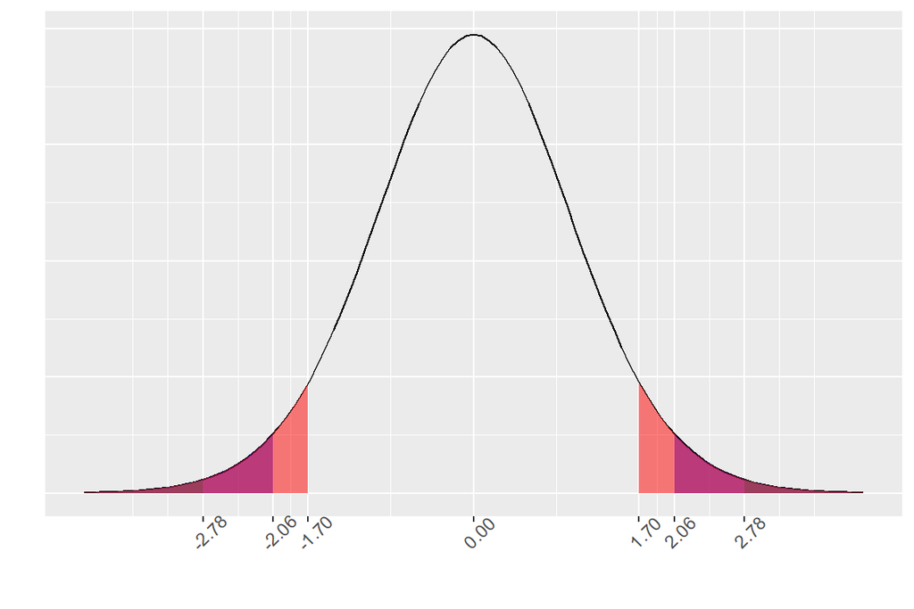

```r
plot_dis_t +
  stat_function(fun = dt,args=list(df =25),xlim = c( 2.78,4),geom = "area",fill = "green",alpha = 0.5) +
  stat_function(fun = dt,args=list(df =25),xlim = c(- 2.78,-4),geom = "area",fill = "green",alpha = 0.5) +
  stat_function(fun = dt,args=list(df =25),xlim = c(2.06,4),geom = "area",fill = "blue",alpha = 0.5) +
  stat_function(fun = dt,args=list(df =25),xlim = c(-2.06,-4),geom = "area",fill = "blue",alpha = 0.5) +
  stat_function(fun = dt,args=list(df =25),xlim = c(1.7,4),geom = "area",fill = "red",alpha = 0.5) +
  stat_function(fun = dt,args=list(df =25),xlim = c(-1.7,-4),geom = "area",fill = "red",alpha = 0.5) +
  scale_x_continuous(breaks= c(-2.78,-2.06,-1.7,0,1.7,2.06,2.78)) +
  theme(axis.text.x = element_text(angle=45))
```

> Regra de bolso.

> À medida que aumentamos os graus de liberdade de uma distribuição t, mais próxima ela irá ficar de uma distribuição normal padronizada. De fato, podemos visualizar isso:

> O valor Z de uma distribuição normal a um nível de significância de 5% é:

```r
alpha <- 0.05
znorm_5 <- qnorm(1-alpha/2) %>% round(2)
znorm_5
```

```
## [1] 1.96
```

> Plotando os valores críticos de t:

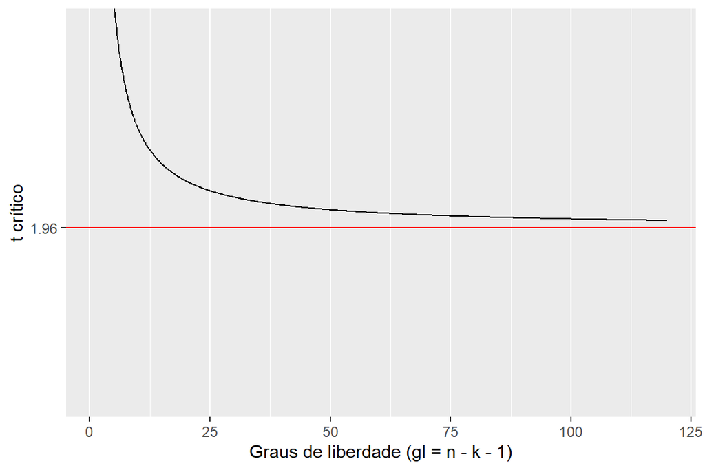

```r
gl <- seq(1,120,0.1)
alpha <- 0.05

tibble(gl = gl,t_critico = qt(1-alpha/2,gl)) %>%
  ggplot()+
  geom_line(aes(x = gl,y =t_critico)) +
  geom_hline(yintercept = qnorm(1-alpha/2), color = "red") +
  coord_cartesian(ylim=c(1.5,2.5)) +
  scale_y_continuous(breaks= znorm_5) +
  xlab("Graus de liberdade (gl = n - k - 1)") +
  ylab("t crítico")
```

> Devido a essa propriedade é comum ver 1.96 sendo utilizado como regra de bolso para o estudo do teste de hipóteses.

##### **3. Finalmente, na prática**

Ao rodar uma regressão no R, a estatística t já é calculada automaticamente:

```r
dados <- gpa1
mod_1 <- lm(colGPA ~ hsGPA + ACT +  skipped,data = gpa1)
mod_1 %>% summary
```

```
##
## Call:
## lm(formula = colGPA ~ hsGPA + ACT + skipped, data = gpa1)
##
## Residuals:
##      Min       1Q   Median       3Q      Max
## -0.85698 -0.23200 -0.03935  0.24816  0.81657
##
## Coefficients:
##             Estimate Std. Error t value Pr(>|t|)
## (Intercept)  1.38955    0.33155   4.191 4.95e-05 ***
## hsGPA        0.41182    0.09367   4.396 2.19e-05 ***
## ACT          0.01472    0.01056   1.393  0.16578
## skipped     -0.08311    0.02600  -3.197  0.00173 **
## ---
## Signif. codes:  0 '***' 0.001 '**' 0.01 '*' 0.05 '.' 0.1 ' ' 1
##
## Residual standard error: 0.3295 on 137 degrees of freedom
## Multiple R-squared:  0.2336, Adjusted R-squared:  0.2168
## F-statistic: 13.92 on 3 and 137 DF,  p-value: 5.653e-08
```

De fato, olhando para a variável hsGPA, se calcularmos a estatística t com a fórmula que derivamos anteriormente chegaremos no mesmo resultado:

```r
b_hsGPA <- 0.41182
dp_hsGPA <- 0.09367

t_hsGPA <- b_hsGPA/dp_hsGPA
t_hsGPA
```

```
## [1] 4.396498
```

Com a estatística em mãos, podemos fazer os testes de hipóteses:

```r
#Calculando os graus de liberdade
gl <- nrow(dados) - 3 - 1
gl
```

```
## [1] 137
```

Com isso a um nível de significância de 5%, o valor crítico é:

```r
qt(1-0.05/2,gl)
```

```
## [1] 1.977431
```

Logo, considerando as hipóteses nula e alternativa:

$H_0:\hat{\beta_j} = 0$

$H_0:\hat{\beta_j} \neq 0$

Como $|t| = 4.3 > 1.97$, rejeitamos a hipótese nula a 5% de significância.

Repare que ao lado dos coeficientes, o R demonstra os resultados dos testes de hipóteses com os asteriscos.

```r
mod_1 %>% summary
```

```
##
## Call:
## lm(formula = colGPA ~ hsGPA + ACT + skipped, data = gpa1)
##
## Residuals:
##      Min       1Q   Median       3Q      Max
## -0.85698 -0.23200 -0.03935  0.24816  0.81657
##
## Coefficients:
##             Estimate Std. Error t value Pr(>|t|)
## (Intercept)  1.38955    0.33155   4.191 4.95e-05 ***
## hsGPA        0.41182    0.09367   4.396 2.19e-05 ***
## ACT          0.01472    0.01056   1.393  0.16578
## skipped     -0.08311    0.02600  -3.197  0.00173 **
## ---
## Signif. codes:  0 '***' 0.001 '**' 0.01 '*' 0.05 '.' 0.1 ' ' 1
##
## Residual standard error: 0.3295 on 137 degrees of freedom
## Multiple R-squared:  0.2336, Adjusted R-squared:  0.2168
## F-statistic: 13.92 on 3 and 137 DF,  p-value: 5.653e-08
```

A variável skipped, por exemplo, tem dois asteriscos que dizem que a variável é estatisticamente significante a um nível de significância de 1%.

Resumo de como o R apresenta o resultado dos testes:

| Nível de signif. | Signif. codes |
| --- | --- |
| 0.1% | *** |
| 1% | ** |
| 5% | * |
| 10% | . |

##### **4. P-valor**

Há um componente de arbitrariedade na escolha do nível de significância adequado. Ainda que 5% seja o mais utilizado, não podemos dizer que este é o mais “correto”. Para diminuir essa ambiguidade, podemos calcular o menor nível de significância no qual rejeitaremos a hipótese nula. Esse valor, será dado pela p-value. Utilizando novamente hsGPA como exemplo:

```r
2*pt(t_hsGPA,df =  137,lower.tail = FALSE)
```

```
## [1] 2.18994e-05
```

O p-valor nesse caso, é evidência contra a hipótese nula a qualquer nível de significância comummente utilizado. Vejamos a variável skipped:

```r
b_skip <- -0.08311
dp_ski <- 0.02600
t_skip <- abs(b_skip/dp_ski)

2*pt(t_skip,df =  137,lower.tail = FALSE)
```

```
## [1] 0.001727107
```

O pvalor da variável skipped é menor que 1% porém maior que 0.1%. Nesse caso, rejeitamos a hipótese nula para qualquer nível de significância maior que 1%.